# Representar el mundo en planos

Geometría constructiva: fundamentos · Clase 1.1

Expresión Gráfica · E.T.S.I. Montes, Forestal y del Medio Natural · UPM

## Representar el mundo en planos

*Las características del dibujo técnico: que sea **gráfico**, **universal** y **preciso**.*

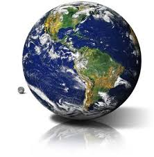

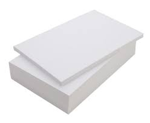

**En INGENIERÍA es CLAVE:**  
mantener la **relación biunívoca**

**DOS problemas:**

- Mundo 3D — plano 2D Sistemas de Representación

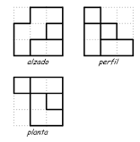

- “Mundo” muy complejo Geometría constructiva

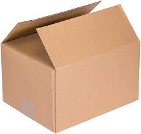

[figure not shown]

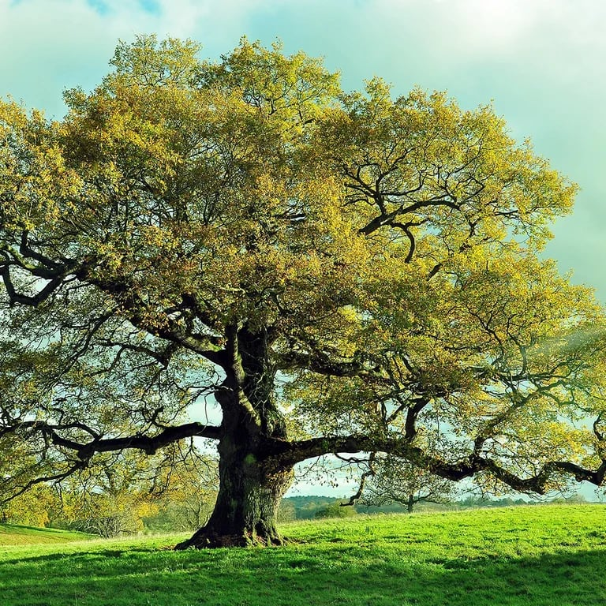

# “Mundo” muy complejo Geometría constructiva

## Geometría constructiva

[figure not shown]

correspondencia biunívoca

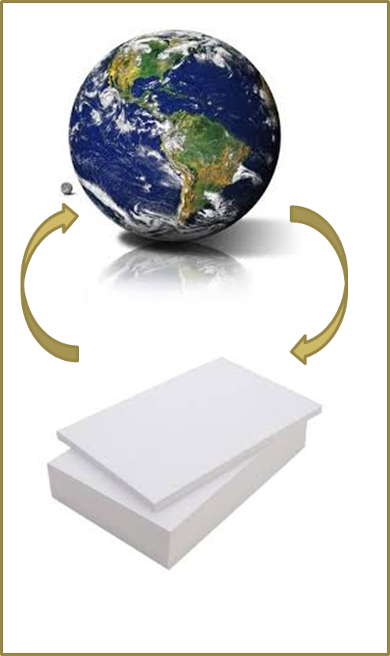

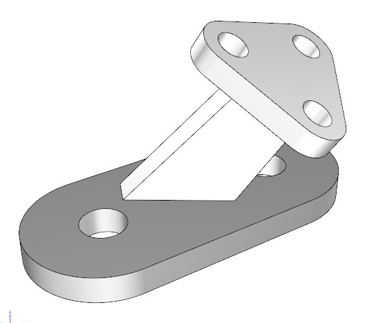

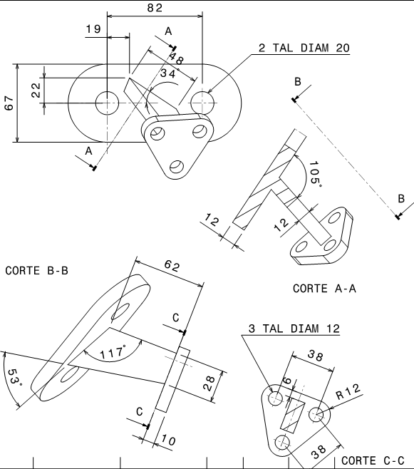

## Correspondencia biunívoca

[figure not shown]

correspondencia biunívoca

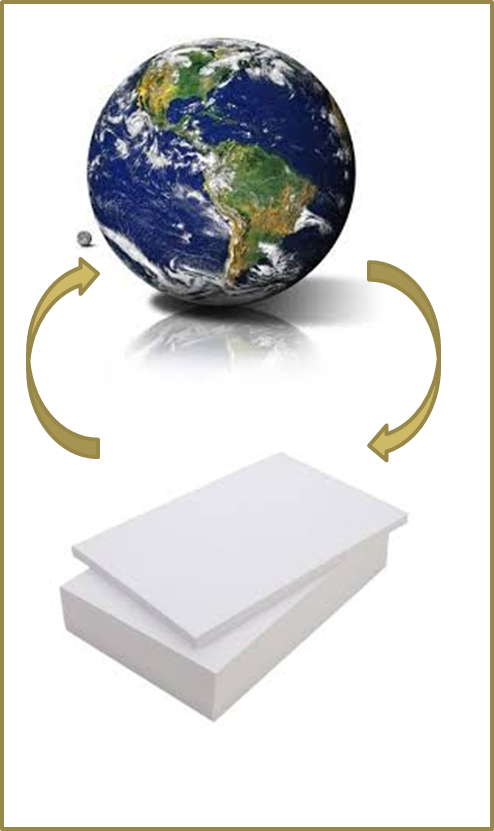

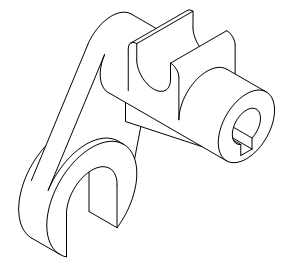

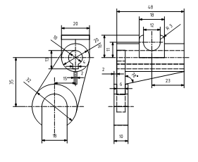

[figure not shown]

¿Qué se puede hacer?  
Dividir los problemas en trozos más pequeños → SIMPLIFICAR

## Modelo de representación de geometría constructiva

1. Se genera el modelo por combinación de **sólidos elementales** o *primitivas sólidas*.
2. Mediante **escalado y movimiento** se sitúan las primitivas en su posición, orientación y tamaño correctos.
3. Se efectúan las **operaciones booleanas** de unión / intersección / diferencia.

[figure not shown]

## Operaciones booleanas

- **Unión** ( ∪ o + ) → junta dos sólidos incluyendo la parte común y no común para crear un nuevo sólido.
- **Intersección** ( ∩ ) → incluye solo la parte común de los dos sólidos, creando un sólido nuevo.
- **Diferencia**, sustracción o resta ( − ) → incluye solo la parte no común del primer sólido.

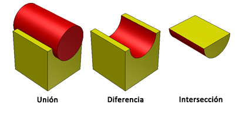

## Volúmenes básicos

- Ortoedro
- Cilindro
- Cono
- Esfera

*Dimensiones necesarias para definirlos*

## Ejemplos: ortoedro (I)

[figure not shown]

## Ejemplos: ortoedro (II)

[figure not shown]

## Ejemplos: cilindro

[figure not shown]

## Ejemplos: cono

[figure not shown]

## Análisis de una pieza

Análisis de una pieza en base a su **descomposición en modelos geométricos elementales** aplicando el *Método Lógico Geométrico*. Aplicación de las operaciones booleanas.

Por otra parte, para DEFINIRLA… ¿cuántas cotas necesita? → *lo vemos el próximo día*

## Materiales auxiliares: croquización

- [Página web con conceptos básicos de croquización](https://ibiguridt.wordpress.com/temas/principios-de-representacion/croquizacion/)
- [Vídeo: dibujar un prisma sencillo en perspectiva caballera (<1’)](https://www.youtube.com/shorts/YPJicwgb4fQ)
- [Vídeo: dibujar varios prismas sencillos en caballera (4’, con explicación verbal)](https://www.youtube.com/watch?app=desktop&v=8BciV_kZQi4)
- [Vídeo: dibujar elipses y cilindros en perspectiva (9’, con reglas útiles)](https://www.youtube.com/watch?v=htyQlm2p7j4)
- [Vídeo: 8 bocetos de 8 objetos a partir de cilindros (11’, para el diseño del Proyecto)](https://www.youtube.com/watch?v=vHut4yk6rFw)

## Cómo practicar

Piezas reales sencillas → **en clase**

Otros ejemplos → [web Piziadas](http://piziadas.com/dibujo/dibujo-tecnico/piezas)

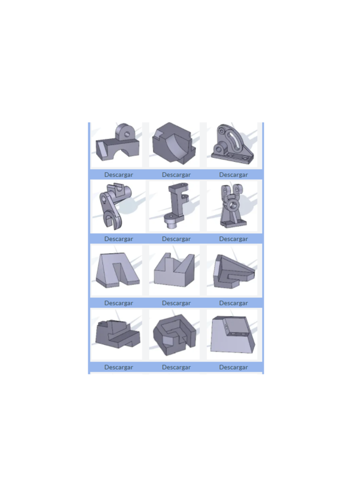

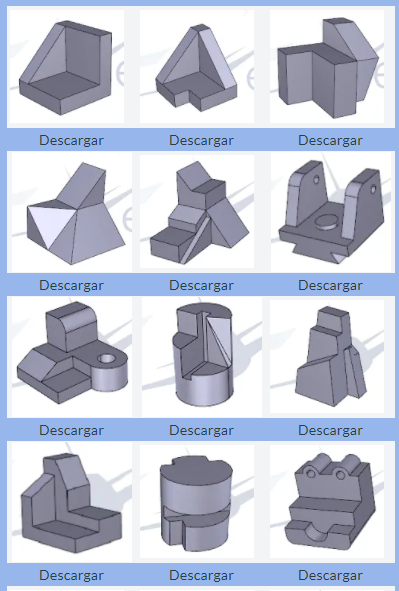

Para visualizar y girar las piezas, descargarlas y guardarlas en pdf.  
Abrirlas con un lector de pdf (no en el navegador) para poder girarlas.